# Accidentes viales en el D.F.

Jessica Barbosa  
15-diciembre-2015

### Descarga de datos

- [Sitio de INEGI](http://www.inegi.org.mx/est/contenidos/proyectos/accesomicrodatos/registros/economicas/accidentes/)
- Microdatos - descarga.
- Seleccionamos año 2014.
- Descarga de .zip con datos y .pdf con metadatos en la subcarpeta **data**.
  - Del .zip tomamos el archivo DBF.
  - Del .pdf tomamos qué significa cada campo.

### Carga de datos en R

Leemos el archivo DBF con ayuda de la librería *foreign*:

```r
#install.packages("foreign")
library("foreign")
#setwd("/home/yo/carpeta_del_proyecto")
datos<-read.dbf("data/atus14.dbf")
head(datos,1)
```

```
  EDO MES ANIO MPIO HORA MINUTOS DIA DIASEMANA URBANA SUBURBANA TIPACCID
1   1   1 2014    5   20      30   2         4      0         2        1
  AUTOMOVIL CAMPASAJ MICROBUS PASCAMION OMNIBUS TRANVIA CAMIONETA CAMION
1         1        0        0         0       0       0         1      0
  TRACTOR FERROCARRI MOTOCICLET BICICLETA OTROVEHIC CAUSAACCI CAPAROD SEXO
1       0          0          0         0         0         1       1    2
  ALIENTO CINTURON EDAD CONDMUERTO CONDHERIDO PASAMUERTO PASAHERIDO
1       6        9   49          0          0          0          0
  PEATMUERTO PEATHERIDO CICLMUERTO CICLHERIDO OTROMUERTO OTROHERIDO
1          0          0          0          0          0          0
  NEMUERTO NEHERIDO
1        0        0
```

### Exploración rápida

```r
nrow(datos)
```

```
[1] 378240
```

```r
ncol(datos)
```

```
[1] 42
```

```r
names(datos)
```

```
 [1] "EDO"        "MES"        "ANIO"       "MPIO"       "HORA"
 [6] "MINUTOS"    "DIA"        "DIASEMANA"  "URBANA"     "SUBURBANA"
[11] "TIPACCID"   "AUTOMOVIL"  "CAMPASAJ"   "MICROBUS"   "PASCAMION"
[16] "OMNIBUS"    "TRANVIA"    "CAMIONETA"  "CAMION"     "TRACTOR"
[21] "FERROCARRI" "MOTOCICLET" "BICICLETA"  "OTROVEHIC"  "CAUSAACCI"
[26] "CAPAROD"    "SEXO"       "ALIENTO"    "CINTURON"   "EDAD"
[31] "CONDMUERTO" "CONDHERIDO" "PASAMUERTO" "PASAHERIDO" "PEATMUERTO"
[36] "PEATHERIDO" "CICLMUERTO" "CICLHERIDO" "OTROMUERTO" "OTROHERIDO"
[41] "NEMUERTO"   "NEHERIDO"
```

### Exploración rápida: Tiempo, lugar, tipo de accidente

```r
summary(datos[,c(1:11,25)])
```

```
      EDO             MES              ANIO           MPIO
 Min.   : 1.00   Min.   : 1.000   Min.   :2014   Min.   :  1.00
 1st Qu.: 9.00   1st Qu.: 4.000   1st Qu.:2014   1st Qu.: 11.00
 Median :16.00   Median : 7.000   Median :2014   Median : 27.00
 Mean   :15.81   Mean   : 6.541   Mean   :2014   Mean   : 36.92
 3rd Qu.:20.00   3rd Qu.:10.000   3rd Qu.:2014   3rd Qu.: 39.00
 Max.   :32.00   Max.   :12.000   Max.   :2014   Max.   :570.00
      HORA          MINUTOS           DIA          DIASEMANA
 Min.   : 0.00   Min.   : 0.00   Min.   : 1.00   Min.   :1.000
 1st Qu.: 8.00   1st Qu.:10.00   1st Qu.: 8.00   1st Qu.:2.000
 Median :13.00   Median :25.00   Median :15.00   Median :4.000
 Mean   :12.86   Mean   :24.52   Mean   :15.51   Mean   :4.072
 3rd Qu.:18.00   3rd Qu.:40.00   3rd Qu.:23.00   3rd Qu.:6.000
 Max.   :23.00   Max.   :59.00   Max.   :31.00   Max.   :7.000
     URBANA        SUBURBANA        TIPACCID        CAUSAACCI
 Min.   :0.000   Min.   :0.000   Min.   : 1.000   Min.   :1.00
 1st Qu.:1.000   1st Qu.:0.000   1st Qu.: 1.000   1st Qu.:1.00
 Median :1.000   Median :0.000   Median : 1.000   Median :1.00
 Mean   :1.153   Mean   :0.139   Mean   : 2.707   Mean   :1.19
 3rd Qu.:1.000   3rd Qu.:0.000   3rd Qu.: 4.000   3rd Qu.:1.00
 Max.   :2.000   Max.   :3.000   Max.   :12.000   Max.   :5.00
```

### Exploración rápida: Vehículos involucrados

```r
summary(datos[,12:24])
```

```
   AUTOMOVIL        CAMPASAJ         MICROBUS         PASCAMION
 Min.   :0.000   Min.   :0.0000   Min.   :0.00000   Min.   :0.00000
 1st Qu.:1.000   1st Qu.:0.0000   1st Qu.:0.00000   1st Qu.:0.00000
 Median :1.000   Median :0.0000   Median :0.00000   Median :0.00000
 Mean   :1.193   Mean   :0.1744   Mean   :0.02725   Mean   :0.05388
 3rd Qu.:2.000   3rd Qu.:0.0000   3rd Qu.:0.00000   3rd Qu.:0.00000
 Max.   :9.000   Max.   :5.0000   Max.   :4.00000   Max.   :4.00000
    OMNIBUS           TRANVIA            CAMIONETA          CAMION
 Min.   :0.00000   Min.   :0.0000000   Min.   :0.0000   Min.   :0.00000
 1st Qu.:0.00000   1st Qu.:0.0000000   1st Qu.:0.0000   1st Qu.:0.00000
 Median :0.00000   Median :0.0000000   Median :0.0000   Median :0.00000
 Mean   :0.01582   Mean   :0.0001533   Mean   :0.1997   Mean   :0.04697
 3rd Qu.:0.00000   3rd Qu.:0.0000000   3rd Qu.:0.0000   3rd Qu.:0.00000
 Max.   :3.00000   Max.   :1.0000000   Max.   :7.0000   Max.   :8.00000
    TRACTOR          FERROCARRI          MOTOCICLET       BICICLETA
 Min.   :0.00000   Min.   :0.0000000   Min.   :0.0000   Min.   :0.00000
 1st Qu.:0.00000   1st Qu.:0.0000000   1st Qu.:0.0000   1st Qu.:0.00000
 Median :0.00000   Median :0.0000000   Median :0.0000   Median :0.00000
 Mean   :0.02518   Mean   :0.0008434   Mean   :0.1107   Mean   :0.01869
 3rd Qu.:0.00000   3rd Qu.:0.0000000   3rd Qu.:0.0000   3rd Qu.:0.00000
 Max.   :9.00000   Max.   :2.0000000   Max.   :4.0000   Max.   :3.00000
   OTROVEHIC
 Min.   :0.00000
 1st Qu.:0.00000
 Median :0.00000
 Mean   :0.03021
 3rd Qu.:0.00000
 Max.   :6.00000
```

### Exploración rápida: Muertos y heridos

```r
summary(datos[,31:42])
```

```
   CONDMUERTO         CONDHERIDO      PASAMUERTO          PASAHERIDO
 Min.   :0.000000   Min.   :0.000   Min.   : 0.000000   Min.   : 0.000
 1st Qu.:0.000000   1st Qu.:0.000   1st Qu.: 0.000000   1st Qu.: 0.000
 Median :0.000000   Median :0.000   Median : 0.000000   Median : 0.000
 Mean   :0.005412   Mean   :0.131   Mean   : 0.003247   Mean   : 0.121
 3rd Qu.:0.000000   3rd Qu.:0.000   3rd Qu.: 0.000000   3rd Qu.: 0.000
 Max.   :3.000000   Max.   :7.000   Max.   :18.000000   Max.   :50.000
   PEATMUERTO        PEATHERIDO        CICLMUERTO          CICLHERIDO
 Min.   :0.00000   Min.   :0.00000   Min.   :0.0000000   Min.   :0.00000
 1st Qu.:0.00000   1st Qu.:0.00000   1st Qu.:0.0000000   1st Qu.:0.00000
 Median :0.00000   Median :0.00000   Median :0.0000000   Median :0.00000
 Mean   :0.00303   Mean   :0.04467   Mean   :0.0006054   Mean   :0.01166
 3rd Qu.:0.00000   3rd Qu.:0.00000   3rd Qu.:0.0000000   3rd Qu.:0.00000
 Max.   :3.00000   Max.   :6.00000   Max.   :3.0000000   Max.   :4.00000
   OTROMUERTO          OTROHERIDO          NEMUERTO    NEHERIDO
 Min.   :0.0000000   Min.   :0.000000   Min.   :0   Min.   :0
 1st Qu.:0.0000000   1st Qu.:0.000000   1st Qu.:0   1st Qu.:0
 Median :0.0000000   Median :0.000000   Median :0   Median :0
 Mean   :0.0001533   Mean   :0.001808   Mean   :0   Mean   :0
 3rd Qu.:0.0000000   3rd Qu.:0.000000   3rd Qu.:0   3rd Qu.:0
 Max.   :3.0000000   Max.   :6.000000   Max.   :0   Max.   :0
```

### Exploración rápida: Gráficas

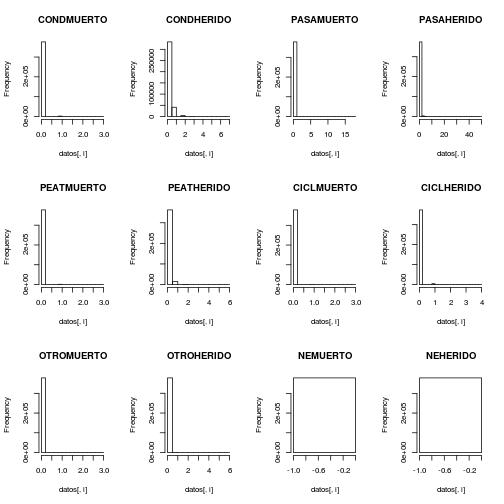

```r
par(mfrow=c(3,4))
for(i in c(31:42)){
  hist(datos[,i],main=names(datos)[i])
}
```

### Datos x Entidad

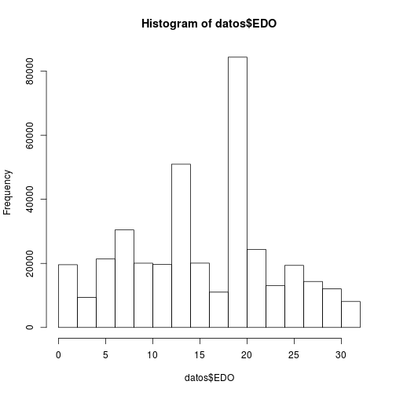

```r
hist(datos$EDO)
```

### Datos x Entidad

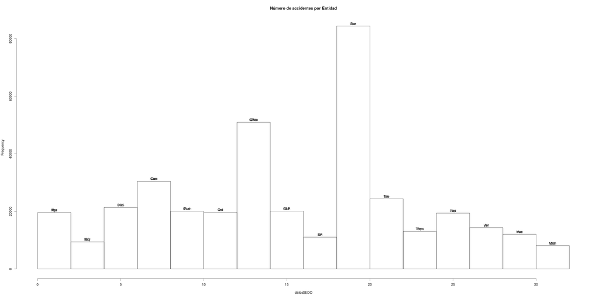

```r
nombres_estados<-c("Ags","BC","BCS","Cam","Coah","Col","Chis","Chih","DF","Dur","Gto","Gro"
                   ,"Hid","Jal","Mex","Mich","Mor","Nay","NL","Oax","Pue","Qro","QRoo","SLP"
                   ,"Sin","Son","Tab","Tmps","Tlax","Ver","Yuc","Zac")
hist(datos$EDO,labels=nombres_estados,main="Número de accidentes por Entidad")
```

### Datos x Entidad

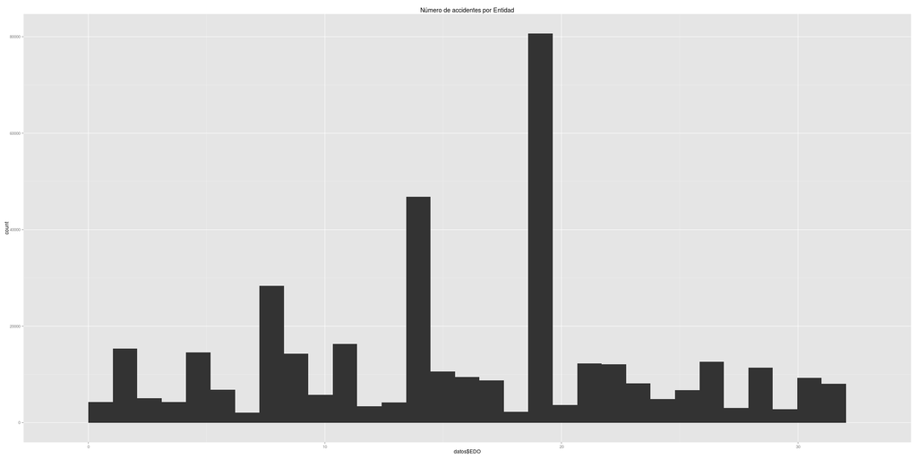

```r
library("ggplot2")
qplot(datos$EDO,main="Número de accidentes por Entidad")
```

### Datos x Entidad

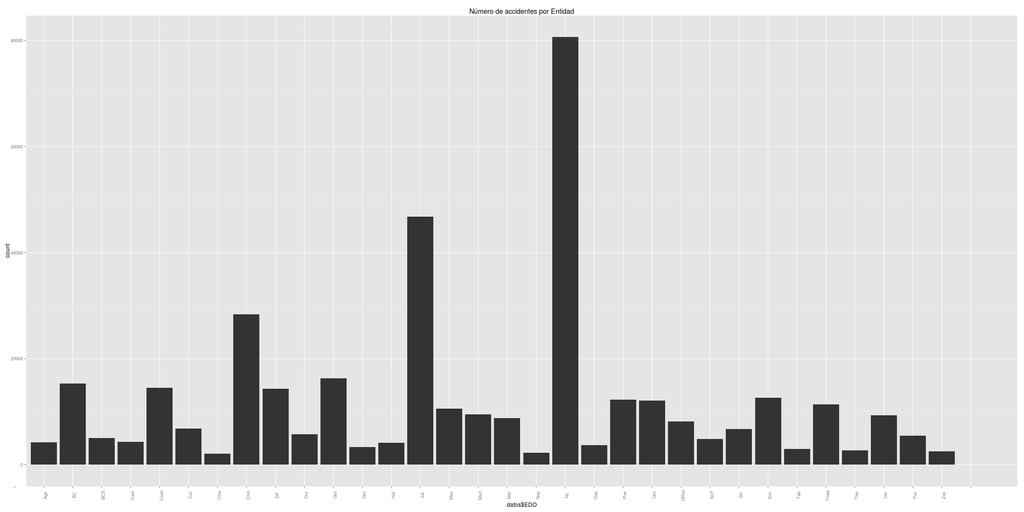

```r
library("ggplot2")
qplot(datos$EDO,main="Número de accidentes por Entidad")+
  scale_x_discrete(labels=c("",nombres_estados)) +
  theme(axis.text.x=element_text(angle=90))
```

### Datos del D.F.

```r
library("dplyr")
datos_df<-filter(datos, EDO == 9)
delegaciones<-c("AObr","Azcap","BJ","Coyo","Cuaj","Cuauh","GAM","Iztac","Iztap","MagC"
                ,"Hid","MAlta","Tlah","Tlal","VCarr","Xoch")
table(datos_df$MPIO)
```

```
   2    3    4    5    6    7    8    9   10   11   12   13   14   15   16
 692 1071  303 1647  690 2113  199   80  918  198  777  339 1133 1820 1281
  17
1058
```

```r
datos_df$MPIO<-datos_df$MPIO-1
table(datos_df$MPIO)
```

```
   1    2    3    4    5    6    7    8    9   10   11   12   13   14   15
 692 1071  303 1647  690 2113  199   80  918  198  777  339 1133 1820 1281
  16
1058
```

### Accidentes x delegación

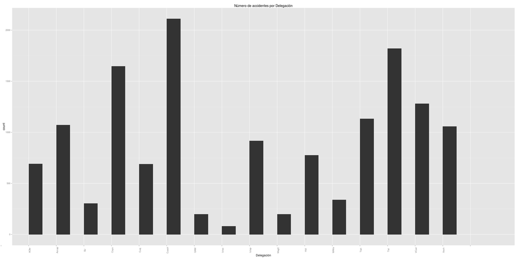

```r
qplot(datos_df$MPIO,main="Número de accidentes por Delegación")+
  scale_x_discrete(labels=c("",delegaciones),name="Delegación") +
  theme(axis.text.x=element_text(angle=90))
```

### Tipos de accidentes

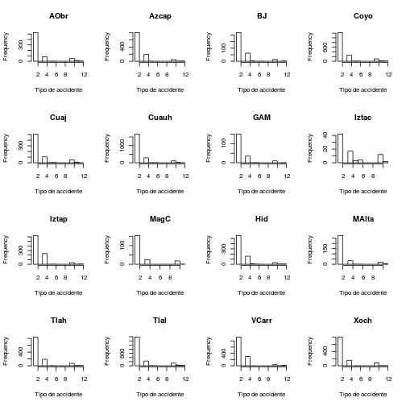

```r
par(mfrow=c(4,4))
for(i in c(1:16)){
  hist(datos_df[datos_df$MPIO == i,"TIPACCID"], main=delegaciones[i], xlab="Tipo de accidente")
}
```

### Tipos de accidentes

*TIPACCID* es una variable categórica:

```
  Clave 1.- Colisión con vehículo automotor
  Clave 2.- Colisión con peatón (atropellamiento)
  Clave 3.- Colisión con animal
  Clave 4.- Colisión con objeto fijo
  Clave 5.- Volcadura
  Clave 6.- Caída de pasajero
  Clave 7.- Salida del camino
  Clave 8.- Incendio
  Clave 9.- Colisión con ferrocarril
  Clave 10.- Colisión con motocicleta
  Clave 11.- Colisión con ciclista
  Clave 12.- Otro
```

### Tipos de accidentes

Convertimos a factores (quitando el 9 porque no hay)

```r
table(datos_df$TIPACCID)
```

```
   1    2    3    4    5    6    7    8   10   11   12
9718 1017    1 2368   69   57    4    1  826  153  105
```

```r
datos_df$tipoacc<-factor(datos_df$TIPACCID,labels=c("Auto","Peatón","Animal","Cosa","Volc"
                                                    ,"Caída","Camino","Fuego","Moto"
                                                    ,"Bici","Otro"))
table(datos_df$tipoacc)
```

```
  Auto Peatón Animal   Cosa   Volc  Caída Camino  Fuego   Moto   Bici
  9718   1017      1   2368     69     57      4      1    826    153
  Otro
   105
```

### Tipos de accidentes

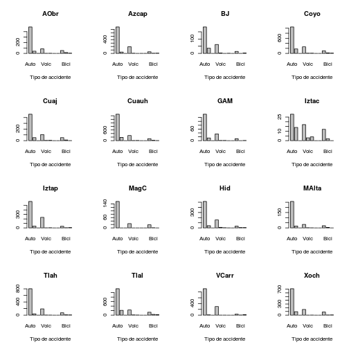

```r
par(mfrow=c(4,4))
for(i in c(1:16)){
  plot(datos_df[datos_df$MPIO == i,"tipoacc"], main=delegaciones[i], xlab="Tipo de accidente")
}
```

### Y un mapita

- Para poder mostrar un mapa necesitamos las coordenadas de los polígonos que conforman cada estado, municipio, etc.
- INEGI tiene esa información. Descargamos municipios [acá](http://mapserver.inegi.org.mx/MGN/mgm2014v6_2.zip)

```
$ cd data
$ wget http://mapserver.inegi.org.mx/MGN/mgm2014v6_2.zip
$ unzip mgm2014v6_2.zip -d shps_inegi
$ ls shps_inegi
mgm2013v6_2.dbf  mgm2013v6_2.prj  mgm2013v6_2.shp  mgm2013v6_2.shx
```

### Y un mapita

```r
#library(maps)
#library(mapdata)
library(maptools)  #for shapefiles
#library(scales)  #for transparency
munis <- readShapePoly("data/shps_inegi/mgm2013v6_2.shp")
head(munis@data)
```

```
  CVE_ENT CVE_MUN               NOM_MUN concat
0      17     001              Amacuzac  17001
1      17     002          Atlatlahucan  17002
2      17     003            Axochiapan  17003
3      17     004                 Ayala  17004
4      17     005 Coatl\xe1n del R\xedo  17005
5      17     006               Cuautla  17006
```

```r
munis_df<-munis[munis@data$CVE_ENT=="09",]
```

### Y un mapita

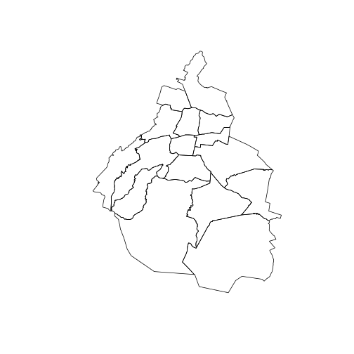

```r
plot(munis_df)
```

### Y un mapita con tipos de accidentes

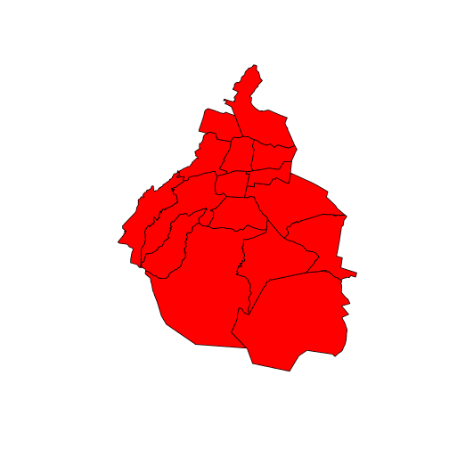

```r
plot(munis_df,col="red")
```

### Y un mapita con tipos de accidentes

- Podemos asociar el color de los municipios al número de accidentes que suceden para cada tipo.
- Problema: la columna *tipoacc* se ve así:

```r
print(datos_df[1:10,"tipoacc"])
```

```
 [1] Cosa Moto Auto Auto Auto Moto Auto Cosa Auto Auto
11 Levels: Auto Peatón Animal Cosa Volc Caída Camino Fuego Moto ... Otro
```

- Es de tipo factor. Tenemos que transformarla a muchas indicadoras; una para cada tipo de accidente para que podamos obtener el número de incidentes de cada tipo por delegación.

### Transformamos un factor

```r
#install.packages("tidyr")
library("tidyr")
datos_df$dummy<-1
sumas_tipoacc<-datos_df %>%
    select(EDO:DIASEMANA,tipoacc,dummy) %>%
     group_by(EDO,MES,ANIO,MPIO,HORA,MINUTOS,DIA,DIASEMANA,tipoacc) %>%
     summarise(num_acc=sum(dummy))
head(sumas_tipoacc)
```

```
Source: local data frame [6 x 10]
Groups: EDO, MES, ANIO, MPIO, HORA, MINUTOS, DIA, DIASEMANA [6]

    EDO   MES  ANIO  MPIO  HORA MINUTOS   DIA DIASEMANA tipoacc num_acc
  (int) (int) (int) (dbl) (int)   (int) (int)     (int)  (fctr)   (dbl)
1     9     1  2014     1     0      23    14         2    Auto       1
2     9     1  2014     1     0      30    21         2    Auto       1
3     9     1  2014     1     0      40    18         6    Auto       1
4     9     1  2014     1     0      45    26         7    Volc       1
5     9     1  2014     1     4       0    18         6    Cosa       1
6     9     1  2014     1     6      30     7         2    Auto       1
```

### Transformamos un factor

Totales por delegación:

```r
totales_tipoacc<-datos_df %>%
    select(MPIO,tipoacc,dummy) %>%
     group_by(MPIO,tipoacc) %>%
     summarise(num_acc=sum(dummy))
totales_tipoacc$MPIO<-sprintf("%03d",(totales_tipoacc$MPIO+1))
head(totales_tipoacc)
```

```
Source: local data frame [6 x 3]
Groups: MPIO [1]

   MPIO tipoacc num_acc
  (chr)  (fctr)   (dbl)
1   002    Auto     487
2   002  Peatón      41
3   002  Animal       1
4   002    Cosa      84
5   002    Volc       2
6   002   Caída       3
```

### Pintamos el mapa según el factor

Necesitamos hacer comparables los mapas por tipo de accidente: misma escala de color.

```r
intervalos<-hist(totales_tipoacc$num_acc,breaks=20,plot=FALSE)$breaks
print(intervalos)
```

```
 [1]    0  100  200  300  400  500  600  700  800  900 1000 1100 1200 1300
[15] 1400 1500
```

Obtenemos los colores:

```r
#install.packages("RColorBrewer")
library(RColorBrewer)
pal <- colorRampPalette(brewer.pal(9, 'Reds'))(length(intervalos))
print(pal)
```

```
 [1] "#FFF5F0" "#FEE9E0" "#FDDDCE" "#FCC9B4" "#FCB59A" "#FC9F81" "#FB8A69"
 [8] "#FB7454" "#F75D42" "#F14432" "#E32F27" "#CF1C1F" "#BB1419" "#A70F15"
[15] "#880711" "#67000D"
```

### Pintamos el mapa según el factor

Asignamos los colores:

```r
head(munis_df@data)
```

```
     CVE_ENT CVE_MUN               NOM_MUN concat
1828      09     002          Azcapotzalco  09002
1829      09     003           Coyoac\xe1n  09003
1830      09     004 Cuajimalpa de Morelos  09004
1831      09     005     Gustavo A. Madero  09005
1832      09     006             Iztacalco  09006
1833      09     007            Iztapalapa  09007
```

```r
totales_tipoacc$colores<-c()
for(i in 1:length(pal))
  totales_tipoacc$colores[totales_tipoacc$num_acc>=intervalos[i]]<-pal[i]
```

### Pintamos el mapa según el factor

```r
par(mfrow=c(2,5))
for(i in c("Auto","Peatón","Animal","Cosa","Volc","Caída","Camino","Moto","Bici","Otro")){
  accidente<-totales_tipoacc[totales_tipoacc$tipoacc==i,]
  munis_df@data$num_acc<-c()
  munis_df@data$tipoacc<-c()
  munis_df@data$colores<-c()
  munis_df@data<-merge(munis_df@data,accidente,by.x="CVE_MUN",by.y="MPIO")
  plot(munis_df,col=munis_df@data$colores,main=i)
}
```

### Pintamos el mapa según el factor

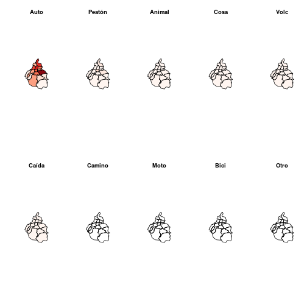

### Algunas conclusiones

- Limpieza y manipulación de datos: **dplyr**, **tidyr**
- Hartos datos:
  - R se come la RAM (**ff**, **bigmemory**, **bigglm**, …)
  - R usa sólo procesador (**snow**,**foreach**,**pdb***)

### Algunas meta-conclusiones

- RStudio: GUI para R.
  - Facilita ejecución de código en R (editor de texto, consola, gráficas,…)
  - Rmarkdown: Facilita creación de PDFs
  - Shiny: Aplicaciones web sencillas.
- Complicado editar las opciones default si uno no sabe TEX, HTML, etc.
- Mi opción usual:
  - .Rmd -> .md -> .tex -> .pdf, el primero vía R, el segundo vía pandoc.

### Referencias

- [Polígonos de México (INEGI)](http://www.inegi.org.mx/geo/contenidos/geoestadistica/m_g_0.aspx)
- [Microdatos de accidentes (INEGI)](http://www.inegi.org.mx/est/contenidos/proyectos/accesomicrodatos/registros/economicas/accidentes/)
- [Esta presentación en github](https://github.com/jbarbosat/mis-desmadres/blob/master/the_data_pub/presentacion.Rpres)
- [Resumen de herramientas de paralelización en R](https://cran.r-project.org/web/views/HighPerformanceComputing.html)